# «Работа с заботой»: Удовлетворенность сотрудников и их отток

```python
pd.DataFrame(
    (
        train_q.query('quit == "yes"')['last_year_promo'].value_counts(
            normalize=True
        )
        - train_q['last_year_promo'].value_counts(normalize=True)
    )
).style.format(formatter={'employment_years': "{0:.0%}"})
```

|  | last_year_promo |
| --- | --- |
| no | 0.041380 |
| yes | -0.041380 |

Среди уволившихся никто не получил продвижение. Это определенно является сигналом.

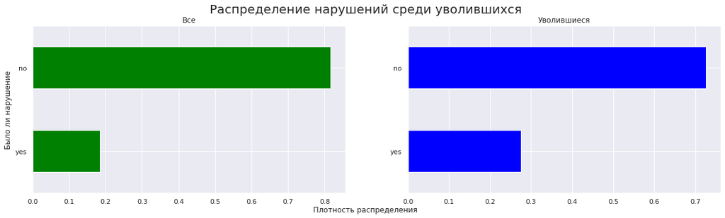

```python
plot_train_test(
    train_q,
    train_q.query('quit == "yes"'),
    'last_year_violations',
    'Распределение нарушений среди уволившихся',
    'Было ли нарушение',
    True,
    'Все',
    'Уволившиеся',
    'Плотность распределения',
)
```

```python
pd.DataFrame(
    (
        train_q.query('quit == "yes"')['last_year_violations'].value_counts(
            normalize=True
        )
        - train_q['last_year_violations'].value_counts(normalize=True)
    )
).style.format(formatter={'employment_years': "{0:.0%}"})
```

|  | last_year_violations |
| --- | --- |
| no | -0.090812 |
| yes | 0.090812 |

Уволившиеся сотрудники чаще нарушают договор.

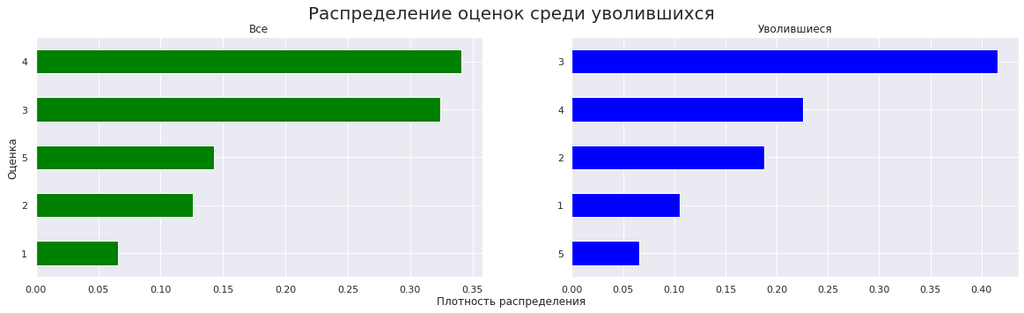

```python
plot_train_test(
    train_q,
    train_q.query('quit == "yes"'),
    'supervisor_evaluation',
    'Распределение оценок среди уволившихся',
    'Оценка',
    True,
    'Все',
    'Уволившиеся',
    'Плотность распределения',
)
```

```python
pd.DataFrame(
    (
        train_q.query('quit == "yes"')['supervisor_evaluation'].value_counts(
            normalize=True
        )
        - train_q['supervisor_evaluation'].value_counts(normalize=True)
    )
).style.format(formatter={'employment_years': "{0:.0%}"})
```

|  | supervisor_evaluation |
| --- | --- |
| 1 | 0.039244 |
| 2 | 0.061772 |
| 3 | 0.090953 |
| 4 | -0.114981 |
| 5 | -0.076987 |

Нельзя сказать, что уволившиеся работают плохо. Большинство получают удовлетворительные и хорошие оценки. Однако, можно заметить, что среди оставшихся меньшинство получает минимальную оценку, а среди уволившихся меньшинство получает максимальную.

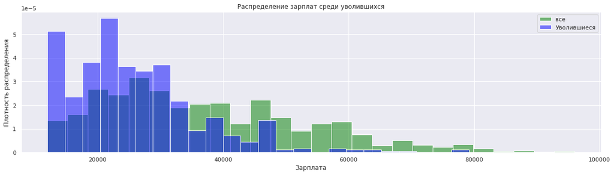

```python
fig, ax = plt.subplots(figsize=(20, 5))
plt.title('Распределение зарплат среди уволившихся')
sns.histplot(
    train_q['salary'],
    stat='density',
    common_norm=False,
    alpha=0.5,
    label='все',
    color='green',
    ax=ax,
)
sns.histplot(
    train_q.query('quit == "yes"')['salary'],
    stat='density',
    common_norm=False,
    alpha=0.5,
    label='Уволившиеся',
    color='blue',
    ax=ax,
)
ax.set(xlabel='Зарплата', ylabel='Плотность распределения')
ax.legend()
plt.show()
```

```python
round(
    train_q.query('quit == "yes"')['salary'].mean()
    / train_q.query('quit == "no"')['salary'].mean(),
    2,
)
```

```
0.63
```

Чаще увольняются сотрудники с низкими зарплатами. Зарплата уволившихся сотрудников в среднем на 37% ниже оставшихся. Можно предположить, что они ищут более доходные место, что вполне логично.

Аналитики утверждают, что уровень удовлетворённости сотрудника работой в компании влияет на то, уволится ли сотрудник. Проверим это утверждение: визуализируем и сравним распределения признака job_satisfaction_rate для ушедших и оставшихся сотрудников. Для этого на тренировочной выборке предскажем показатель, воспользовавшись нашей лучшей моделью, а на тестовой выборке - воспользуемся результатами из предыдущей задачи.

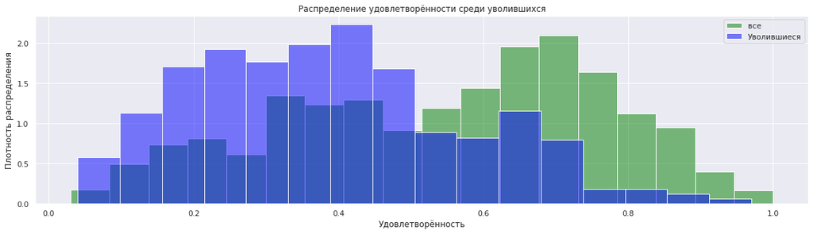

```python
portrait = X_test_q.merge(y_test_q, left_index=True, right_index=True).merge(
    y_test, left_index=True, right_index=True
)

fig, ax = plt.subplots(figsize=(20, 5))
plt.title('Распределение удовлетворённости среди уволившихся')
sns.histplot(
    portrait['job_satisfaction_rate'],
    stat='density',
    common_norm=False,
    alpha=0.5,
    label='все',
    color='green',
    ax=ax,
)
sns.histplot(
    portrait.query('quit == "yes"')['job_satisfaction_rate'],
    stat='density',
    common_norm=False,
    alpha=0.5,
    label='Уволившиеся',
    color='blue',
    ax=ax,
)
ax.set(xlabel='Удовлетворённость', ylabel='Плотность распределения')
ax.legend()
plt.show()
```

```python
round(
    portrait.query('quit == "yes"')['job_satisfaction_rate'].mean()
    / portrait.query('quit == "no"')['job_satisfaction_rate'].mean(),
    2,
)
```

```
0.63
```

Действительно, можно заметить, что в среднем уровень удовлетворённости уволившихся на 37% ниже оставшихся.

### Моделирование

#### Подготовка данных

```python
# Подготовим тренировочный датасет
X_train_q = train_q.drop(['quit'], axis=1)
y_train_q = train_q['quit']

# Тестовый датасет соединим и разделим, чтобы убедиться,
# что записи соответствуют друг другу
test_q_df = X_test_q.merge(y_test_q, left_index=True, right_index=True)
X_test_q = test_q_df.drop(['quit'], axis=1)
y_test_q = test_q_df['quit']
```

Сделаем предсказания удовлетворенности теста

```python
X_train_q['job_satisfaction_rate'] = best_regressor.predict(X_train_q)
X_test_q['job_satisfaction_rate'] = best_regressor.predict(X_test_q)
```

Обработчик для разных типов колонок можно оставить из предыдущей модели. Только в численные колонки нужно добавить `job_satisfaction_rate`. Также нужно закодировать переменную `quit`.

```python
num_cols.append('job_satisfaction_rate')
```

```python
lab_encoder = LabelEncoder()

lab_encoder.fit(['no', 'yes'])

y_train_q = lab_encoder.transform(y_train_q)
y_test_q = lab_encoder.transform(y_test_q)
```

В стандартной модели заменим регрессор на классификатор.

```python
pipe_final = Pipeline(
    # Финальный пайплайн
    [
        ('preprocessor', data_preprocessor),
        ('model', DecisionTreeClassifier(random_state=RANDOM_STATE)),
    ]
)
```

#### Поиск модели и обработки

Проверим разные модели с разными гиперпараметрами. Также попробуем разные обработчики числовых переменных.

```python
# Параметры для LogisticRegression
logreg_params = {}

logreg_params['preprocessor__num'] = [
    StandardScaler(),
    MinMaxScaler(),
    RobustScaler(),
]


logreg_params['model__penalty'] = ['l2', 'l1']
logreg_params['model'] = [
    LogisticRegression(
        random_state=RANDOM_STATE, solver='liblinear', max_iter=1000
    )
]


# Параметры для KNeighborsClassifier
knn_params = {}

knn_params['preprocessor__num'] = [
    StandardScaler(),
    MinMaxScaler(),
    RobustScaler(),
]

knn_params['model'] = [KNeighborsClassifier()]

# Параметры для DecisionTreeClassifier
tree_params = {}

tree_params['preprocessor__num'] = [
    StandardScaler(),
    MinMaxScaler(),
    RobustScaler(),
]

tree_params['model__max_depth'] = [None]
tree_params['model__min_samples_leaf'] = range(10, 15)
tree_params['model__min_samples_split'] = range(50, 65)
tree_params['model__max_leaf_nodes'] = range(440, 450)
tree_params['model'] = [DecisionTreeClassifier(random_state=RANDOM_STATE)]

# Параметры для SVC
svc_params = {}

svc_params['preprocessor__num'] = [
    StandardScaler(),
    MinMaxScaler(),
    RobustScaler(),
]

svc_params['model'] = [SVC(probability=True, random_state=RANDOM_STATE)]

params = [logreg_params, knn_params, tree_params, svc_params]
```

```python
grid_class = GridSearchCV(
    pipe_final, params, cv=5, n_jobs=-1, scoring='roc_auc'
)
```

```python
grid_class.fit(X_train_q, y_train_q)
```

```
GridSearchCV(cv=5,
             estimator=Pipeline(steps=[('preprocessor',
                                        ColumnTransformer(remainder='passthrough',
                                                          transformers=[('ohe',
                                                                         Pipeline(steps=[('simpleImputer_ohe',
                                                                                          SimpleImputer(strategy='most_frequent')),
                                                                                         ('ohe',
                                                                                          OneHotEncoder(drop='first',
                                                                                                        handle_unknown='ignore',
                                                                                                        sparse_output=False))]),
                                                                         ['dept',
                                                                          'last_year_promo',
                                                                          'last_year_violations']),
                                                                        ('ord',
                                                                         Pipeline(...
                          'model__max_depth': [None],
                          'model__max_leaf_nodes': range(440, 450),
                          'model__min_samples_leaf': range(10, 15),
                          'model__min_samples_split': range(50, 65),
                          'preprocessor__num': [StandardScaler(),
                                                MinMaxScaler(),
                                                RobustScaler()]},
                         {'model': [SVC(probability=True, random_state=42)],
                          'preprocessor__num': [StandardScaler(),
                                                MinMaxScaler(),
                                                RobustScaler()]}],
             scoring='roc_auc')
```

```python
best_classifier = grid_class.best_estimator_
best_classifier
```

```
Pipeline(steps=[('preprocessor',
                 ColumnTransformer(remainder='passthrough',
                                   transformers=[('ohe',
                                                  Pipeline(steps=[('simpleImputer_ohe',
                                                                   SimpleImputer(strategy='most_frequent')),
                                                                  ('ohe',
                                                                   OneHotEncoder(drop='first',
                                                                                 handle_unknown='ignore',
                                                                                 sparse_output=False))]),
                                                  ['dept', 'last_year_promo',
                                                   'last_year_violations']),
                                                 ('ord',
                                                  Pipeline(steps=[('simpleImputer_befor...
                                                                                  handle_unknown='use_encoded_value',
                                                                                  unknown_value=nan)),
                                                                  ('simpleImputer_after_ord',
                                                                   SimpleImputer(strategy='most_frequent'))]),
                                                  ['level', 'workload']),
                                                 ('num', StandardScaler(),
                                                  ['salary',
                                                   'supervisor_evaluation',
                                                   'employment_years',
                                                   'job_satisfaction_rate'])])),
                ('model',
                 DecisionTreeClassifier(max_leaf_nodes=440, min_samples_leaf=11,
                                        min_samples_split=63,
                                        random_state=42))])
```

```python
# roc_auc на кросс-валидации
grid_class.best_score_
```

```
0.9025852772966607
```

### Предсказание увольнения

```python
y_pred_q = best_classifier.predict_proba(X_test_q)
```

```python
roc_auc_score(y_test_q, y_pred_q[:, 1])
```

```
0.9216444171161027
```

Снова лучше всего показало себя дерево решений

```python
# Сравним с DummyClassifier
dummy_class = DummyClassifier(strategy='uniform')
dummy_class.fit(X_train_q, y_train_q)
dummy_class_pred = dummy_class.predict_proba(X_test_q)
roc_auc_score(y_test_q, dummy_class_pred[:, 1])
```

```
0.5
```

roc_auc модели значительно превосходит DummyClassifier

#### Сравнение разных моделей

```python
results_df_class = pd.DataFrame(grid_class.cv_results_)
results_df_class = results_df_class.sort_values(by=["rank_test_score"])
results_df_class = results_df_class.set_index(
    results_df_class["params"].apply(
        lambda x: "_".join(str(val) for val in x.values())
    )
).rename_axis("kernel")
results_df_class[
    ["params", "rank_test_score", "mean_test_score", "std_test_score"]
].head()
```

| kernel | params | rank_test_score | mean_test_score | std_test_score |
| --- | --- | --- | --- | --- |
| DecisionTreeClassifier(random_state=42)_None_448_11_63_RobustScaler() | {'model': DecisionTreeClassifier(random_state=... | 1 | 0.902585 | 0.014836 |
| DecisionTreeClassifier(random_state=42)_None_449_11_64_RobustScaler() | {'model': DecisionTreeClassifier(random_state=... | 1 | 0.902585 | 0.014836 |
| DecisionTreeClassifier(random_state=42)_None_444_11_63_StandardScaler() | {'model': DecisionTreeClassifier(random_state=... | 1 | 0.902585 | 0.014836 |
| DecisionTreeClassifier(random_state=42)_None_444_11_63_MinMaxScaler() | {'model': DecisionTreeClassifier(random_state=... | 1 | 0.902585 | 0.014836 |
| DecisionTreeClassifier(random_state=42)_None_444_11_63_RobustScaler() | {'model': DecisionTreeClassifier(random_state=... | 1 | 0.902585 | 0.014836 |

## Общий вывод

Перед нами стояло две задачи:

1. Предсказать уровень удовлетворённости сотрудника работой;
2. Предсказать возможность его увольнения;

**Что мы сделали:**:

- Загрузили и обработали данные: проверили наличие дублей и пропущенных значений. Обнаружили ошибки при заполнении таблиц и исправили их;
- Провели исследовательский анализ данных: посмотрели, как сбалансированы классы, как распределяются переменные в разных разрезах;
- Провели корреляционный анализ, мультиколлинеарности не обнаружили;
- Создали собственную метрику для оценки модели - SMAPE;
- Обучили регрессионную модель для предсказания удовлетворённости сотрудника, получив отличный результат - SMAPE = 13%;
- Воспользовались результатами регрессионной модели, чтобы обогатить датасет для второй задачи;
- Выяснили, что удовлетворенность сотрудника - один из важнейших признаков, указывающих на риск увольнения;

**Рекомендации для бизнеса:**

1. Следить за уровнем загрузки сотрудников. Если сотруднику нечем заняться, скорее всего, он уйдёт, потому что:
   - Ему не за что просить повышение в должности, а грейд сотрудника - самый важный параметр, указывающий на увольнение
   - Ему не за что просить повешение зарплаты, которая тоже важна
   - Ему нечего будет написать в резюме
   - Ему просто скучно, у него достаточно времени, чтобы подумать об увольнении и сходить на собеседования
   - Он не чувствует, что важен компании. Что он вообще тут делает?
2. Разработать прозрачную схему повышений, чтобы каждый сотрудник понимал, что именно он должен сделать, чтобы повысить грейд
3. Разработать возможность горизонтального перемещения между отделами. Возможно, человек просто находится не на своём месте
4. Стараться удерживать сотрудников. Чем дольше сотрудник работает, тем менее вероятно, что он уйдёт
5. Проводить оценки работы и давать сотруднику понять, что именно от него требуется, чтобы его работу высоко оценили